# Project: Investigate a Dataset (TMDb Movie Dataset Analysis)

- Introduction
- Data Wrangling
- Exploratory Data Analysis
- Conclusions

## Introduction

> **In this project, I'll be analyzing data associated with movies from TMDb database and this dataset contains information about 10,000 movies that includes movie's original title, popularity,budget,rating,revnue and others.I'll be intrested to find more about these data pattrens and some relationships between some variables.**

## Questions

> 1-What are the top 10 movies with Highest Revenue?  
> 2-What are the top 10 movies with highest Budget?  
> 3-What are the top 10 movies with highest Profit?  
> 4-What are the top 10 most popular movies?  
> 5-Is there a relationship between the movie's popularity and its profit?  
> 6-Is there a relationship between the movie's avrerage voting and its popularity?  
> 7-Is there a relationship between the movie's Profit and its Budget?  
> 8-Which genre has the highest release of movies?  
> 9-Which year has the highest number of movies released from 1970 to 2016?  
> 10-Which length of movies are the most popularly watched by people?

```python
#Import the necessary Libraries for analysis
import pandas as pd
from pandas import Series,DataFrame
import numpy as np
import matplotlib as plt
import seaborn as sns
%matplotlib inline
```

## Data Wrangling

In this section, I'll be loading the dataset then go through all data cleaning process needed to get the dataset ready for further analysis.

### General Properties

```python
# Loading the data
df=pd.read_csv('tmdb-movies.csv')
#print out a the first 5 lines.
df.head()
```

|  | id | imdb_id | popularity | budget | revenue | original_title | cast | homepage | director | tagline | ... | overview | runtime | genres | production_companies | release_date | vote_count | vote_average | release_year | budget_adj | revenue_adj |
| --- | --- | --- | --- | --- | --- | --- | --- | --- | --- | --- | --- | --- | --- | --- | --- | --- | --- | --- | --- | --- | --- |
| 0 | 135397 | tt0369610 | 32.985763 | 150000000 | 1513528810 | Jurassic World | Chris Pratt\|Bryce Dallas Howard\|Irrfan Khan\|Vi... | http://www.jurassicworld.com/ | Colin Trevorrow | The park is open. | ... | Twenty-two years after the events of Jurassic ... | 124 | Action\|Adventure\|Science Fiction\|Thriller | Universal Studios\|Amblin Entertainment\|Legenda... | 6/9/15 | 5562 | 6.5 | 2015 | 1.379999e+08 | 1.392446e+09 |
| 1 | 76341 | tt1392190 | 28.419936 | 150000000 | 378436354 | Mad Max: Fury Road | Tom Hardy\|Charlize Theron\|Hugh Keays-Byrne\|Nic... | http://www.madmaxmovie.com/ | George Miller | What a Lovely Day. | ... | An apocalyptic story set in the furthest reach... | 120 | Action\|Adventure\|Science Fiction\|Thriller | Village Roadshow Pictures\|Kennedy Miller Produ... | 5/13/15 | 6185 | 7.1 | 2015 | 1.379999e+08 | 3.481613e+08 |
| 2 | 262500 | tt2908446 | 13.112507 | 110000000 | 295238201 | Insurgent | Shailene Woodley\|Theo James\|Kate Winslet\|Ansel... | http://www.thedivergentseries.movie/#insurgent | Robert Schwentke | One Choice Can Destroy You | ... | Beatrice Prior must confront her inner demons ... | 119 | Adventure\|Science Fiction\|Thriller | Summit Entertainment\|Mandeville Films\|Red Wago... | 3/18/15 | 2480 | 6.3 | 2015 | 1.012000e+08 | 2.716190e+08 |
| 3 | 140607 | tt2488496 | 11.173104 | 200000000 | 2068178225 | Star Wars: The Force Awakens | Harrison Ford\|Mark Hamill\|Carrie Fisher\|Adam D... | http://www.starwars.com/films/star-wars-episod... | J.J. Abrams | Every generation has a story. | ... | Thirty years after defeating the Galactic Empi... | 136 | Action\|Adventure\|Science Fiction\|Fantasy | Lucasfilm\|Truenorth Productions\|Bad Robot | 12/15/15 | 5292 | 7.5 | 2015 | 1.839999e+08 | 1.902723e+09 |
| 4 | 168259 | tt2820852 | 9.335014 | 190000000 | 1506249360 | Furious 7 | Vin Diesel\|Paul Walker\|Jason Statham\|Michelle ... | http://www.furious7.com/ | James Wan | Vengeance Hits Home | ... | Deckard Shaw seeks revenge against Dominic Tor... | 137 | Action\|Crime\|Thriller | Universal Pictures\|Original Film\|Media Rights ... | 4/1/15 | 2947 | 7.3 | 2015 | 1.747999e+08 | 1.385749e+09 |

5 rows × 21 columns

```python
#print out the last 5 lines.
df.tail(5)
```

|  | id | imdb_id | popularity | budget | revenue | original_title | cast | homepage | director | tagline | ... | overview | runtime | genres | production_companies | release_date | vote_count | vote_average | release_year | budget_adj | revenue_adj |
| --- | --- | --- | --- | --- | --- | --- | --- | --- | --- | --- | --- | --- | --- | --- | --- | --- | --- | --- | --- | --- | --- |
| 10861 | 21 | tt0060371 | 0.080598 | 0 | 0 | The Endless Summer | Michael Hynson\|Robert August\|Lord 'Tally Ho' B... | NaN | Bruce Brown | NaN | ... | The Endless Summer, by Bruce Brown, is one of ... | 95 | Documentary | Bruce Brown Films | 6/15/66 | 11 | 7.4 | 1966 | 0.000000 | 0.0 |
| 10862 | 20379 | tt0060472 | 0.065543 | 0 | 0 | Grand Prix | James Garner\|Eva Marie Saint\|Yves Montand\|Tosh... | NaN | John Frankenheimer | Cinerama sweeps YOU into a drama of speed and ... | ... | Grand Prix driver Pete Aron is fired by his te... | 176 | Action\|Adventure\|Drama | Cherokee Productions\|Joel Productions\|Douglas ... | 12/21/66 | 20 | 5.7 | 1966 | 0.000000 | 0.0 |
| 10863 | 39768 | tt0060161 | 0.065141 | 0 | 0 | Beregis Avtomobilya | Innokentiy Smoktunovskiy\|Oleg Efremov\|Georgi Z... | NaN | Eldar Ryazanov | NaN | ... | An insurance agent who moonlights as a carthie... | 94 | Mystery\|Comedy | Mosfilm | 1/1/66 | 11 | 6.5 | 1966 | 0.000000 | 0.0 |
| 10864 | 21449 | tt0061177 | 0.064317 | 0 | 0 | What's Up, Tiger Lily? | Tatsuya Mihashi\|Akiko Wakabayashi\|Mie Hama\|Joh... | NaN | Woody Allen | WOODY ALLEN STRIKES BACK! | ... | In comic Woody Allen's film debut, he took the... | 80 | Action\|Comedy | Benedict Pictures Corp. | 11/2/66 | 22 | 5.4 | 1966 | 0.000000 | 0.0 |
| 10865 | 22293 | tt0060666 | 0.035919 | 19000 | 0 | Manos: The Hands of Fate | Harold P. Warren\|Tom Neyman\|John Reynolds\|Dian... | NaN | Harold P. Warren | It's Shocking! It's Beyond Your Imagination! | ... | A family gets lost on the road and stumbles up... | 74 | Horror | Norm-Iris | 11/15/66 | 15 | 1.5 | 1966 | 127642.279154 | 0.0 |

5 rows × 21 columns

```python
#Print a summary of the database
df.info()
```

```
<class 'pandas.core.frame.DataFrame'>
RangeIndex: 10866 entries, 0 to 10865
Data columns (total 21 columns):
id                      10866 non-null int64
imdb_id                 10856 non-null object
popularity              10866 non-null float64
budget                  10866 non-null int64
revenue                 10866 non-null int64
original_title          10866 non-null object
cast                    10790 non-null object
homepage                2936 non-null object
director                10822 non-null object
tagline                 8042 non-null object
keywords                9373 non-null object
overview                10862 non-null object
runtime                 10866 non-null int64
genres                  10843 non-null object
production_companies    9836 non-null object
release_date            10866 non-null object
vote_count              10866 non-null int64
vote_average            10866 non-null float64
release_year            10866 non-null int64
budget_adj              10866 non-null float64
revenue_adj             10866 non-null float64
dtypes: float64(4), int64(6), object(11)
memory usage: 1.7+ MB
```

```python
#To present a describtive summary of the data
df.describe()
```

|  | id | popularity | budget | revenue | runtime | vote_count | vote_average | release_year | budget_adj | revenue_adj |
| --- | --- | --- | --- | --- | --- | --- | --- | --- | --- | --- |
| count | 10866.000000 | 10866.000000 | 1.086600e+04 | 1.086600e+04 | 10866.000000 | 10866.000000 | 10866.000000 | 10866.000000 | 1.086600e+04 | 1.086600e+04 |
| mean | 66064.177434 | 0.646441 | 1.462570e+07 | 3.982332e+07 | 102.070863 | 217.389748 | 5.974922 | 2001.322658 | 1.755104e+07 | 5.136436e+07 |
| std | 92130.136561 | 1.000185 | 3.091321e+07 | 1.170035e+08 | 31.381405 | 575.619058 | 0.935142 | 12.812941 | 3.430616e+07 | 1.446325e+08 |
| min | 5.000000 | 0.000065 | 0.000000e+00 | 0.000000e+00 | 0.000000 | 10.000000 | 1.500000 | 1960.000000 | 0.000000e+00 | 0.000000e+00 |
| 25% | 10596.250000 | 0.207583 | 0.000000e+00 | 0.000000e+00 | 90.000000 | 17.000000 | 5.400000 | 1995.000000 | 0.000000e+00 | 0.000000e+00 |
| 50% | 20669.000000 | 0.383856 | 0.000000e+00 | 0.000000e+00 | 99.000000 | 38.000000 | 6.000000 | 2006.000000 | 0.000000e+00 | 0.000000e+00 |
| 75% | 75610.000000 | 0.713817 | 1.500000e+07 | 2.400000e+07 | 111.000000 | 145.750000 | 6.600000 | 2011.000000 | 2.085325e+07 | 3.369710e+07 |
| max | 417859.000000 | 32.985763 | 4.250000e+08 | 2.781506e+09 | 900.000000 | 9767.000000 | 9.200000 | 2015.000000 | 4.250000e+08 | 2.827124e+09 |

#### Notice:

**The total rows 10866 and total colums 21.However,there are some missing data need to be filled or droped and some incorrect data types. All these issues will be solved in the next step of data analysis proccess (Data Cleaning)**

### Data Cleaning

#### 1-Removing Data Duplication

**In this step, I'll remove any duplicated data rows,which is very important step in any data cleaning (wringling) process. In order to keep the data clean and consistant and ready for analysis.**

```python
#check if there is a duplicate data
df.duplicated()
```

[output not shown]

[output cut: 47 more lines]

```python
#To see how many duplicated rows
sum(df.duplicated())
```

```
1
```

```python
#To remove duplication
df.drop_duplicates(inplace=True)
#After removing duplication, display the new number of (rows,columns)
df.shape
```

```
(10865, 21)
```

#### 2-Removing Unused Columns

**In this step, I'll remove any column that Not needed in the analysis such as the columns overview, Imdb_id, homepage and so on..**

```python
#Droppd the unused columns
df.drop(['budget_adj','revenue_adj','overview','imdb_id','homepage','tagline','director','cast','keywords','production_companies'],axis=1,inplace=True)
```

```python
#To show the new data set after removing the unused columns
df.head()
```

|  | id | popularity | budget | revenue | original_title | runtime | genres | release_date | vote_count | vote_average | release_year |
| --- | --- | --- | --- | --- | --- | --- | --- | --- | --- | --- | --- |
| 0 | 135397 | 32.985763 | 150000000 | 1513528810 | Jurassic World | 124 | Action\|Adventure\|Science Fiction\|Thriller | 6/9/15 | 5562 | 6.5 | 2015 |
| 1 | 76341 | 28.419936 | 150000000 | 378436354 | Mad Max: Fury Road | 120 | Action\|Adventure\|Science Fiction\|Thriller | 5/13/15 | 6185 | 7.1 | 2015 |
| 2 | 262500 | 13.112507 | 110000000 | 295238201 | Insurgent | 119 | Adventure\|Science Fiction\|Thriller | 3/18/15 | 2480 | 6.3 | 2015 |
| 3 | 140607 | 11.173104 | 200000000 | 2068178225 | Star Wars: The Force Awakens | 136 | Action\|Adventure\|Science Fiction\|Fantasy | 12/15/15 | 5292 | 7.5 | 2015 |
| 4 | 168259 | 9.335014 | 190000000 | 1506249360 | Furious 7 | 137 | Action\|Crime\|Thriller | 4/1/15 | 2947 | 7.3 | 2015 |

#### 3-Checking Appropriate Data Types

**In this step,I'll check if the data have approriate data types or not**

```python
#To show a summary of the data set
df.info()
```

```
<class 'pandas.core.frame.DataFrame'>
Int64Index: 10865 entries, 0 to 10865
Data columns (total 11 columns):
id                10865 non-null int64
popularity        10865 non-null float64
budget            10865 non-null int64
revenue           10865 non-null int64
original_title    10865 non-null object
runtime           10865 non-null int64
genres            10842 non-null object
release_date      10865 non-null object
vote_count        10865 non-null int64
vote_average      10865 non-null float64
release_year      10865 non-null int64
dtypes: float64(2), int64(6), object(3)
memory usage: 1018.6+ KB
```

```python
#Since the 'release_date' data type is object, it must be converted to a Date type
df['release_date']=pd.to_datetime(df['release_date'])

#To see the change reflected
df.info()
```

```
<class 'pandas.core.frame.DataFrame'>
Int64Index: 10865 entries, 0 to 10865
Data columns (total 11 columns):
id                10865 non-null int64
popularity        10865 non-null float64
budget            10865 non-null int64
revenue           10865 non-null int64
original_title    10865 non-null object
runtime           10865 non-null int64
genres            10842 non-null object
release_date      10865 non-null datetime64[ns]
vote_count        10865 non-null int64
vote_average      10865 non-null float64
release_year      10865 non-null int64
dtypes: datetime64[ns](1), float64(2), int64(6), object(2)
memory usage: 1018.6+ KB
```

```python
#Since the above data info shows that there are null values, I'll check how many null values in the data set.
df.isnull().sum()
```

```
id                 0
popularity         0
budget             0
revenue            0
original_title     0
runtime            0
genres            23
release_date       0
vote_count         0
vote_average       0
release_year       0
dtype: int64
```

**Since we have null values in'generes' and these data types are String (object),so I can't use the mean of these data to fill the null values. That's why I desided to drop them.**

```python
#Drop rows that contain null values in genres and production_companies

df['genres'] = df['genres'].replace(0,np.NaN)

df.dropna(inplace =True)
```

```python
#Checking the data after removing null values
df.isnull().sum()
```

```
id                0
popularity        0
budget            0
revenue           0
original_title    0
runtime           0
genres            0
release_date      0
vote_count        0
vote_average      0
release_year      0
dtype: int64
```

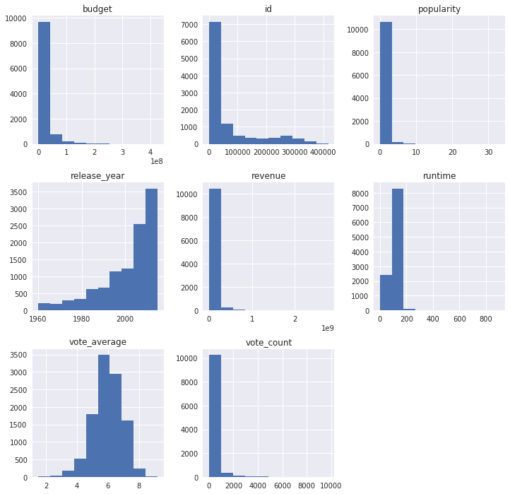

```python
#View overall distribution of the dataset
df.hist(figsize=(12,12));
```

**From above histograms, I observed that there are zero values in some data rows!, it seems that the data set is not yet ready to go to the next step in the data analysis process. Before that, this is the final step in data wringling I need to do(Replacing 0 values in the data with the mean)**

#### 5-Replacing rows with zero values in budget, revengue and runtime with thier means

```python
#Checking for 0 values in the data
print("Zero Values In The id Column:",df[(df['id']==0)].shape[0])
print("Zero Values In The Budget Column:",df[(df['budget']==0)].shape[0])
print("Zero Values In The Revenue Column:",df[(df['revenue']==0)].shape[0])
print("Zero Values In The Popularity Column:",df[(df['popularity']==0)].shape[0])
print("Zero Values In The Release_year Column:",df[(df['release_year']==0)].shape[0])
print("Zero Values In The Vote_average Column:",df[(df['vote_average']==0)].shape[0])
print("Zero Values In The Vote count Column:",df[(df['vote_count']==0)].shape[0])
print("Zero Values In The Run time Column:",df[(df['runtime']==0)].shape[0])
```

```
Zero Values In The id Column: 0
Zero Values In The Budget Column: 5674
Zero Values In The Revenue Column: 5993
Zero Values In The Popularity Column: 0
Zero Values In The Release_year Column: 0
Zero Values In The Vote_average Column: 0
Zero Values In The Vote count Column: 0
Zero Values In The Run time Column: 30
```

**There is another approch to solve this issue which is droping these 0 values and removing it from the data set. However,since there are many 0 values in the data and dropping might couse missing so important data that leads to inaccurate conclusion.That's why I decided to calculate the mena and replace these zeros with it.**

```python
#Replacing rows with zero values in budget, revenue and Runtime with thier means
df['budget']=df['budget'].replace(0,df['budget'].mean())
df['revenue']=df['revenue'].replace(0,df['revenue'].mean())
df['runtime']=df['runtime'].replace(0,df['runtime'].mean())
df.replace(inplace =True)
```

```
id                None
popularity        None
budget            None
revenue           None
original_title    None
runtime           None
genres            None
release_date      None
vote_count        None
vote_average      None
release_year      None
dtype: object
```

```python
#Making sure that all 0 values are replaced with the mean
print("Zero Values In The Run time Column:",df[(df['runtime']==0)].shape[0])
print("Zero Values In The Budget Column:",df[(df['budget']==0)].shape[0])
print("Zero Values In The Revenue Column:",df[(df['revenue']==0)].shape[0])
```

```
Zero Values In The Run time Column: 0
Zero Values In The Budget Column: 0
Zero Values In The Revenue Column: 0
```

**Now, I have the needed columns,and rows are cleaned with the correct data forms and the data set is cleaned. Next step, investigating and exploring the data with answering the questions**

## Exploratory Data Analysis

In this section,I will explore and analysis the data to answer the questions posed in the beginning of the project.Also, take a deep look into studing some statistics and building visualization to analysis relationships between variables.

### Research Question 1 (What are the top 10 movies with Highest Revenue? )

```python
R_revenue = pd.DataFrame(df.nlargest(10,'revenue')[['budget','revenue','original_title']]).set_index('original_title');

#Devide revenue by 1000,000 to make data clearer
R_revenue ['budget'] = R_revenue['budget']/1000000
R_revenue['revenue'] = R_revenue['revenue']/1000000

R_revenue.head(10)
```

| original_title | budget | revenue |
| --- | --- | --- |
| Avatar | 237.0 | 2781.505847 |
| Star Wars: The Force Awakens | 200.0 | 2068.178225 |
| Titanic | 200.0 | 1845.034188 |
| The Avengers | 220.0 | 1519.557910 |
| Jurassic World | 150.0 | 1513.528810 |
| Furious 7 | 190.0 | 1506.249360 |
| Avengers: Age of Ultron | 280.0 | 1405.035767 |
| Harry Potter and the Deathly Hallows: Part 2 | 125.0 | 1327.817822 |
| Frozen | 150.0 | 1274.219009 |
| Iron Man 3 | 200.0 | 1215.439994 |

**This table represents the top 10 movies with highest revenue. Obviously, Avatar has made the highest revenue, then Star Wars,Titanic, The Avengers and so on.**

### Research Question 2 (What are the top 10 movies with highest Budget?)

```python
H_budget = pd.DataFrame(df.nlargest(10,'budget')[['budget','revenue','original_title']]).set_index('original_title');

#Devide budget and revenue by 1000,000 to make the data clearer
H_budget['budget']= H_budget['budget']/1000000

H_budget['revenue'] =H_budget['revenue']/1000000

H_budget.head(10)
```

| original_title | budget | revenue |
| --- | --- | --- |
| The Warrior's Way | 425.0 | 11.087569 |
| Pirates of the Caribbean: On Stranger Tides | 380.0 | 1021.683000 |
| Pirates of the Caribbean: At World's End | 300.0 | 961.000000 |
| Avengers: Age of Ultron | 280.0 | 1405.035767 |
| Superman Returns | 270.0 | 391.081192 |
| Tangled | 260.0 | 591.794936 |
| John Carter | 260.0 | 284.139100 |
| Spider-Man 3 | 258.0 | 890.871626 |
| The Lone Ranger | 255.0 | 89.289910 |
| The Hobbit: The Battle of the Five Armies | 250.0 | 955.119788 |

**This table represents top 10 movies with highest budget.In which The Warrior's Way budget($425 million), Pirates of the Caribbean: On Stranger Tides budget($380 million)and so on.**

### Research Question 3 (What are the top 10 movies with highest Profit?)

```python
# I need to calculate the Profit first, 'profit= revenue-budget'
df['profit'] =df['revenue']-df['budget']
P_profit = pd.DataFrame(df.nlargest(10,'profit')[['budget','revenue','profit','original_title']]).set_index('original_title');

#Divide the data by 1000,000 to make it clearer

P_profit['budget']=P_profit['budget']/1000000
P_profit['revenue']=P_profit['revenue']/1000000

P_profit['profit']=P_profit['profit']/1000000

P_profit.head(10)
```

| original_title | budget | revenue | profit |
| --- | --- | --- | --- |
| Avatar | 237.0 | 2781.505847 | 2544.505847 |
| Star Wars: The Force Awakens | 200.0 | 2068.178225 | 1868.178225 |
| Titanic | 200.0 | 1845.034188 | 1645.034188 |
| Jurassic World | 150.0 | 1513.528810 | 1363.528810 |
| Furious 7 | 190.0 | 1506.249360 | 1316.249360 |
| The Avengers | 220.0 | 1519.557910 | 1299.557910 |
| Harry Potter and the Deathly Hallows: Part 2 | 125.0 | 1327.817822 | 1202.817822 |
| Avengers: Age of Ultron | 280.0 | 1405.035767 | 1125.035767 |
| Frozen | 150.0 | 1274.219009 | 1124.219009 |
| The Net | 22.0 | 1106.279658 | 1084.279658 |

**This table shows the top 10 movies made the highest profit. We can see Avatar is made the highest profit then Star Wars: The Force Awakens and then Titanic and so on.**

### Research Question 4((What are the top 10 most popular movies?)

```python
popularity=pd.DataFrame(df.nlargest(10,'popularity')[['popularity','budget','revenue','profit','original_title']]).set_index('original_title');

#Divide the data by 1000,000 to make it clearer
popularity['budget']=popularity['budget']/1000000
popularity['revenue']=popularity['revenue']/1000000
popularity['profit']=popularity['profit']/1000000

popularity.head(10)
```

| original_title | popularity | budget | revenue | profit |
| --- | --- | --- | --- | --- |
| Jurassic World | 32.985763 | 150.0 | 1513.528810 | 1363.528810 |
| Mad Max: Fury Road | 28.419936 | 150.0 | 378.436354 | 228.436354 |
| Interstellar | 24.949134 | 165.0 | 621.752480 | 456.752480 |
| Guardians of the Galaxy | 14.311205 | 170.0 | 773.312399 | 603.312399 |
| Insurgent | 13.112507 | 110.0 | 295.238201 | 185.238201 |
| Captain America: The Winter Soldier | 12.971027 | 170.0 | 714.766572 | 544.766572 |
| Star Wars | 12.037933 | 11.0 | 775.398007 | 764.398007 |
| John Wick | 11.422751 | 20.0 | 78.739897 | 58.739897 |
| Star Wars: The Force Awakens | 11.173104 | 200.0 | 2068.178225 | 1868.178225 |
| The Hunger Games: Mockingjay - Part 1 | 10.739009 | 125.0 | 752.100229 | 627.100229 |

**We can see from the above table Jurassic Worldis the most popular movie, then Mad Max: Fury Road and next Interstellar and so on.**

### Research Question 5 (Is there a relationship between the movie's popularity and its profit?)

```
0.60034205149586606
```

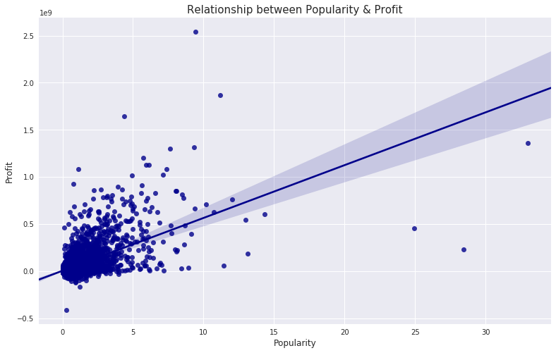

```python
#Create a scatter plot to show the relationship between popularity and porfit

ax= sns.regplot(x=df['popularity'],y=df['profit'],color='Darkblue')

ax.set_title("Relationship between Popularity & Profit",fontsize=15)
ax.set_xlabel("Popularity",fontsize=12)
ax.set_ylabel("Profit",fontsize=12)

sns.set(rc={'figure.figsize':(13,8)})

#calculate the correlation coefficient
def correlation_coe(x,y):
    C_x=(x-x.mean())/x.std(ddof=0)
    C_y=(y-y.mean())/y.std(ddof=0)
    return(C_x*C_y).mean()

correlation_coe(df['popularity'],df['profit'])
```

### Research Question 6 (Is there a relationship between the movie's avrerage voting and its popularity?)

```
0.21043216454493019
```

[figure not shown]

```python
#Create a scatter plot to show the relationship between popularity and vote_average

ax = sns.regplot(x=df['popularity'],y=df['vote_average'],color='Darkblue')

ax.set_title("Relatiobship between Popularity & Vote_average",fontsize=15)
ax.set_xlabel("vote_average",fontsize=13)
ax.set_ylabel("popularity",fontsize=13)

sns.set(rc={'figure.figsize':(13,8)})

#calculate the correlation coefficient
def correlation_coef(x,y):
    s_x=(x-x.mean())/x.std(ddof=0)
    s_y=(y-y.mean())/y.std(ddof=0)
    return(s_x*s_y).mean()

correlation_coef(df['popularity'],df['vote_average'])
```

### Research Question 7 (Is there a relationship between the movie's Profit and its Budget?)

```
0.53854049107825508
```

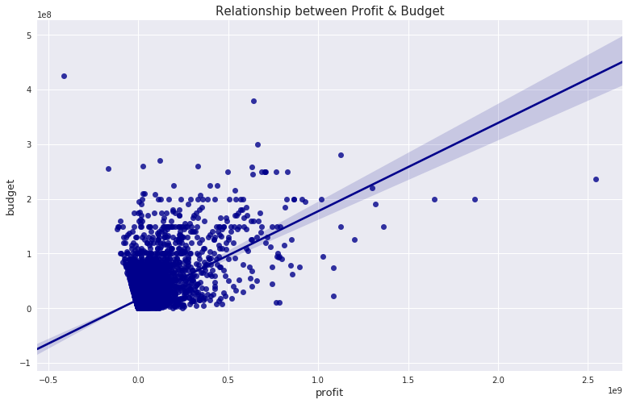

```python
#make a scatter plot using 'regplot' between 'profit' and 'budget'.
ax = sns.regplot(x=df['profit'], y=df['budget'],color='Darkblue')

#title and the labels of the plot.
ax.set_title("Relationship between Profit & Budget",fontsize=15)
ax.set_xlabel("profit",fontsize=13)
ax.set_ylabel("budget",fontsize=13)

sns.set(rc={'figure.figsize':(13,8)})

#calculate the correlation coefficient
def correlation_co(x,y):
    s_x=(x-x.mean())/x.std(ddof=0)
    s_y=(y-y.mean())/y.std(ddof=0)
    return(s_x*s_y).mean()

correlation_co(df['profit'],df['budget'])
```

**Is there a relationship between the movie's Profit and its Budget? from the relationship above, Profit and Budget have a positive correlation(0.53). It means that movies with high budgets are most likely have high Profit.**

### Research Question 8 (Which genre has the highest release of movies?)

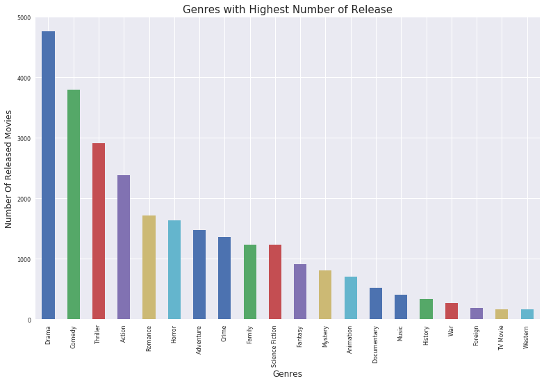

```python
#split 'genres' and return the count of each genre.
def count_genres(f):
    #concatenate all the rows of the genrs.
    data_plot=df[f].str.cat(sep = '|')
    data= pd.Series(data_plot.split('|'))

    gen= data.value_counts(ascending=False)
    return gen

#counting the movies for each genre
total= count_genres('genres')
total=total.plot(kind= 'bar',figsize = (13,8),fontsize=8)

total.set_title("Genres with Highest Number of Release",fontsize=15)
total.set_xlabel("Genres",fontsize=12)
total.set_ylabel("Number Of Released Movies",fontsize= 12)
sns.set_style("whitegrid")
```

**From the above Bar chart, we can observe that Drama genre has the highest release of movies more than 4000 released movies, than Comedy genre with more than 3000 movies and so on.**

### Research Question 9 (Which year has the highest number of movies released from 1970 to 2016?)

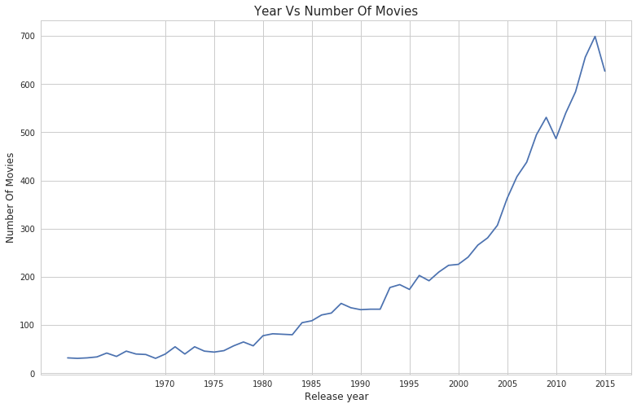

```python
#Using groupby to group each year and count the number of movies in each year
ax=df.groupby('release_year').count()['id']
ax=df.groupby('release_year').count()['id'].plot(kind='line',xticks = np.arange(1970,2016,5))
#figure size and labels
sns.set(rc={'figure.figsize':(15,10)})
ax.set_title("Year Vs Number Of Movies",fontsize = 15)
ax.set_xlabel('Release year',fontsize = 12)
ax.set_ylabel('Number Of Movies',fontsize = 12)
sns.set_style("whitegrid")
```

### Research Question 10 (Which length of movies are the most popularly watched by people? )

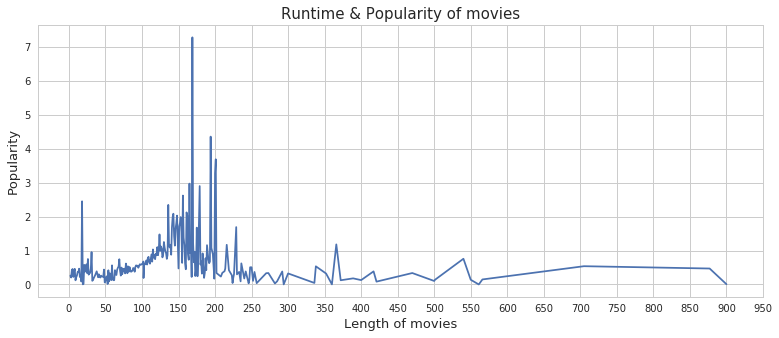

```python
#using groupby to group the movie runtime
ax=df.groupby('runtime')['popularity'].mean().plot(kind='line',figsize = (13,5),xticks=np.arange(0,1000,50))

ax.set_title("Runtime & Popularity of movies",fontsize = 15)

ax.set_xlabel('Length of movies',fontsize = 13)
ax.set_ylabel('Popularity',fontsize = 13)

sns.set(rc={'figure.figsize':(18,12)})
sns.set_style("whitegrid")
```

**As shown in the line chart, movies in the range of 120 to 200 mins are more popular than others. People tend to watch movies in this range much more than longer movies.**

## Conclusions

### Limitations:

In data wrangling process, particularly in 'genres' columns there were more than one genre in the same row for each movie so I used '|' to split the data in data exploring step. This took a long time and efforts to calculate the results.  
Also, this analysis may not be 100% accurate, due to missing 'null' values in data and some data with 0 values. All data cleaning proccess has been done to make sure the data is clean and complete as much as possible. Although there are some limitation in the findings led back to the same reasons mentioned above.

```python
from subprocess import call
call(['python', '-m', 'nbconvert', 'Investigate_a_Dataset.ipynb'])
```